# Poblacion_AGEB

**Limpieza de base de datos y Sph de Poblacion total por AGEB**

**En este documento se describe la metodología empleada para la limpieza de datos poblacional, creacion del sph de población total por AGEB y la dealizacion de histogramas, se trabajo con dos sofwares Rstudio y ArcGis de este proceso se obtuvo la capa de poblacion total e histogramas en formato jpg**

**Limpiesa de base de datos en Rstudio**

Como insumos se utilizo la capa de AGEB descargada del marco Geoestadistico en formato sph [INEGI,2020](https://www.inegi.org.mx/temas/mg/#Descargas). y del Censo de Poblacion de vivienda 2020 en formato csv [INEGI,2020](https://www.inegi.org.mx/servicios/datosabiertos.html).

Se creo un proyecto de Poblacion_AGEB el cual se debe de guardar en : C:\Tesis_Katia\Proyectos los insumos de este proyecto son las carpetas: ageb_poblacion y area_estudio coyo path es: C:\Tesis_Katia\Capas  
Este proyecto contiene la capa final del procesamiento

La base de datos utilizada se encuentra en la carpeta base de datos la cual contiene dos archivos:  
1.- conjunto_de_datos_ageb_urbana_11_cpv2020 : Archivo descargado del inegi 2.- Poblacion_ISC : Archivo con datos filtrados solo de los municipios que estan en nuestra zona de estudio

Para limpiar la base de datos se tubieron que tomar en cuenta las siguientes consideraciones con relación a la información de censo de Población y vivienda 2020:

**1.** Los valores nulos estan expresados con *, hay que sustituir estos valores por ceros para poder realizar el análisis estadístico  
**2.** Las columnas que contienen información de población son de tipo caracter por lo que no se puedes procesar númericamente, por lo tanto hay que cambiar el tipo de dato a númerico.  
**3.** Los AGEB de cada municipio no tienen un valor unico por lo que hay que procesar cada municipio por separado para que al momento de unir lo con la geometría no se le asigne un valor erroneo a cada polígono  
**3.** La base de datos no solo contiene información por cada municipio si no que también tiene valores de población total, hay que filtrar los datos para que estos valores no afecten el análisis, el filtro se realizará con el campo manzana =0 ya que es una característica única de estos reguistros de población total  
**4.** La información de la base de datos da la informacion de la población en función de cada manzana y no respecto a cada AGEB por lo que es importante agrupar los valores por AGEB y hacer la suma de la población total formando una base de datos para cada AGEB  
**5.** Para nuestro analísis no nos interesan los AGEB con poblacion total igual a cero por lo que hay que hacer un filtro de esos valores

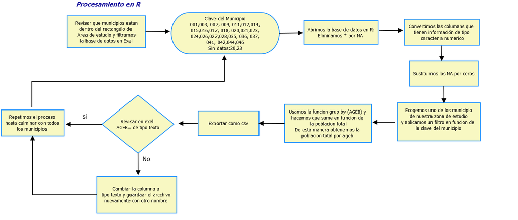

**Las librerias utilizadas para la limpeza de datos fuerón:**

1.- library(dplyr)  
2.- library(readxl)

```python
El codigo empleado en Rstudio fue el siguiente:

    ##IMPORTAMOS EL CSV
poblacion <- read.csv("Poblacion_ISC.csv", header = TRUE )
## Asignamos valores vacios a los que tienen asteriscos

poblacion[poblacion=="*"] <- ""

###cambiomos el tipo de dato de chr a num de la columna 8 en adelante

poblacion<- poblacion %>% as_tibble() %>% mutate(across(c(8:ncol(.)), as.numeric))

 ###Revisamos que el tipo de dato sea numerico
str(poblacion)

# Vamos a hacer un filtro para aquellos datos cuya manzana sea diferente de cero

poblacion<- poblacion %>% filter(MZA!=0)
# Vamos a hacer un filtro para aquellos datos cuya poblacion total sea diferente de cero
poblacion<- poblacion %>% filter(POBTOT!=0)
# Vamos a hacer un filtro por municipio el valor de mun=x depende de la clave del municipio
poblacion<- poblacion %>% filter(MUN==X


## Procedemos a cambiar los NA por ceros


poblacion[is.na(poblacion)] <- 0
View(poblacion)

## Hacemos un analisis por AGEB usando group by y obtenemos la suma que sera la población total por AGEB Y el número de manzanas
##que se sumaron


pobtotal<-poblacion %>%  group_by(AGEB) %>% summarise( POB_T = sum(POBTOT), N_MZ = n())


##Exportar csv colocando el numero de municipio donde esta la X para no confundirnos

write.csv(pobtotal, file="pobtotal_0X.csv")
```

**Detalles importantes:** Este código se corrio para cada uno de los municipios en los que se encuentra nuestra zona de estudio los municpios 020 y 023 no contenian informacio

**Creación de sph de Población total por AGEB**

**1.** Para realizar el join tenemos que hacerlo en función de un campo en común el sph tiene el campo CVE_AGEB y la base de datos que hicimos prebiamente tiene el campo AGEB  
**2.** El campo AGEB de nuestra base de datos no coincide con el del sph ya que para los datos númericos tienen un cero antes del numero  
**3.** El tipo de dato de nuestra base de datos y el sph deben de coincidir de lo contrario hay que abrir la base de datos en exel y cambiar el tipo de dato posteriormente se tiene que volver a exportar el archivo ya que no siempre se guarda este tipo de cambios en la base de datos original  
**3.** Para hacer el marge todos los sph deben de tener los mismos campos con los mismos nombres, esto generara que todos los datos de las tabla de atributos coincidan y obtendremos una tabla "completa"

**Nota:** Para solucionar la consideracion 2 creamos un nuevo campo de tipo numerico y nombre A, ordenamos la columna CVE_AGEB y seleccionamos todos los valores númericos damos clic izquierdo en la parte superior del campo que acabamos de crear y abrimos la calculadora ráster colocamos A = CVE_AGEB, nos va a salir una ventana con un error por que el campo CVE_AGEB tiene datos de tipo texto pero le damos en ok --> después damos clic en la parte superior del campo CVE_AGEB y abrimos la calculadora de campos colocamos CVE_AGEB= A y damos ok, de esta manera eliminamos el cero que tenia al inicio los valores númericos y nuestro campo es de tipo texto

**Procedimiento:**

1.- Se realizo un clip usando como input feature la capa de AGEB y como clip feature la capa de area de estudio

2.-Posteriormente se creo un sph por cada municipio usando la funcion select by attributes escribir CVE_MUN= 'x'porteriormente se esporto la capa como sph, la x representa la clave del municipio

3.-Una vez creadas las capas se hizo un join con la base de datos correspondiente a cada municipio. El campo en común para realizár el join fue CVE_AGEB para el sph y AGEB para la base de datos

4.- Se revisó que todas las capas tuvieran los siguientes campos en la tabla de atributos, en caso contrario eliminar el campo:  
OBJECTID  
CVEGEO  
CVE_ENT  
CVE_MUN  
CVE_LOC  
CVE_AGEB  
POB_T  
N_MZ

5.- Finalmente se realizo un marge de todas las capas, en el diagrama de flujo estan las claves de los municipios que se utilizaron para este analisis

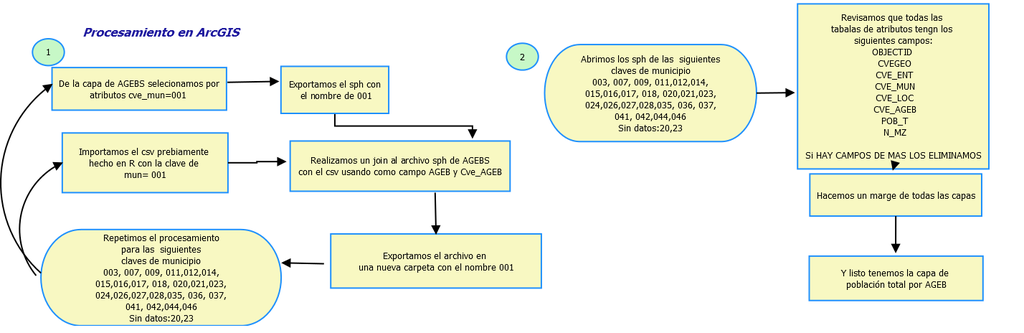